# Regression analysis - Assignment 4

Edgar Manrique

5/10/2022

We are going to explore data from the London Ward Stats, trying to fit a linear model to predict Average GCSE scores. As an example we are going to use the median age of the ward.

```r
library(sf)
library(tidyverse)
library(patchwork)
library(RColorBrewer)

df <- st_read('~/Desktop/SpatStat/class 5/LondonWardStats/LondonWardStats.shp')
Regressiondata <- df %>%
  dplyr::select(Average.GC, Median.Age) |>
  filter(complete.cases(Average.GC, Median.Age))
```

The first thing would be to visually interpret the spatial distribution of the two variables. The dependent variable is on the top (GCSE) and the independent variable (Median age) on the bottom.

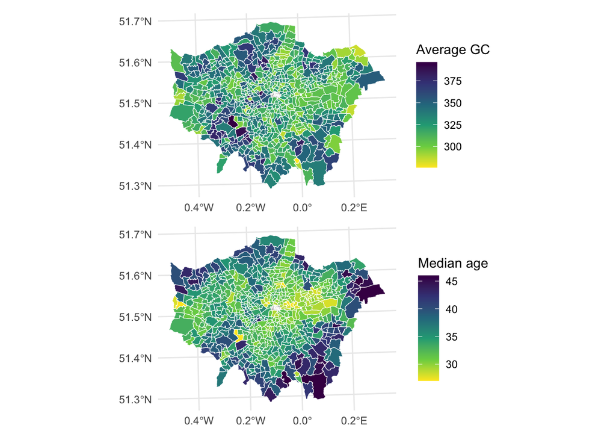

```r
g1 <- ggplot(df) +
  geom_sf(aes(fill = Average.GC), color = 'white', size = .2) +
  scale_fill_viridis_c(direction = -1)+
  coord_sf() +
  theme_minimal() +
  labs(fill = 'Average GC')

g2 <- ggplot(df) +
  geom_sf(aes(fill = Median.Age), color = 'white', size = .2) +
  scale_fill_viridis_c(direction = -1)+
  coord_sf() +
  theme_minimal() +
  labs(fill = 'Median age')

g <- g1 / g2
g
```

We can see that there could be a correlation between the two variables as places with higher values in median age also present higher values in GCSE.

We can further explore the linear relation by using a scatterplot:

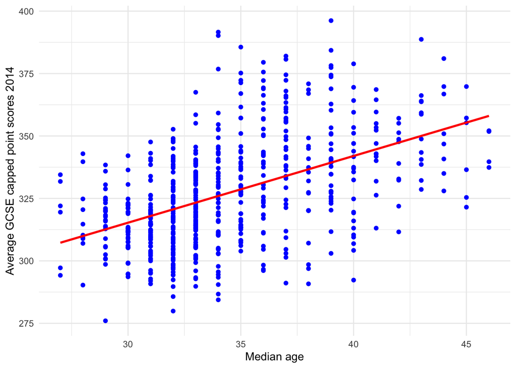

```r
ggplot2::ggplot(Regressiondata,
                aes(
                  x = Median.Age,
                  y = Average.GC
                )
) +
  ggplot2::xlab("Median age") +
  ggplot2::ylab("Average GCSE capped point scores 2014") +
  ggplot2::geom_point(color="blue") +
  ggplot2::geom_smooth(method=lm , color="red", fill="#69b3a2",
                       se=FALSE) +
  ggplot2::theme_minimal()
```

Now we can fit a linear model and see how well the GCSE is explained by the median age:

```r
#now model
model1 <- Regressiondata %>%
  lm(Average.GC ~ Median.Age, data=.)
#show the summary of those outputs
summary(model1)
```

```
##
## Call:
## lm(formula = Average.GC ~ Median.Age, data = .)
##
## Residuals:
##     Min      1Q  Median      3Q     Max
## -49.708 -12.858  -1.581  11.297  65.628
##
## Coefficients:
##             Estimate Std. Error t value Pr(>|t|)
## (Intercept) 235.1002     6.6227    35.5   <2e-16 ***
## Median.Age    2.6727     0.1909    14.0   <2e-16 ***
## ---
## Signif. codes:  0 '***' 0.001 '**' 0.01 '*' 0.05 '.' 0.1 ' ' 1
##
## Residual standard error: 18.81 on 622 degrees of freedom
## Multiple R-squared:  0.2396, Adjusted R-squared:  0.2384
## F-statistic:   196 on 1 and 622 DF,  p-value: < 2.2e-16
```

```r
Regressiondata$residuals <- model1$residuals
```

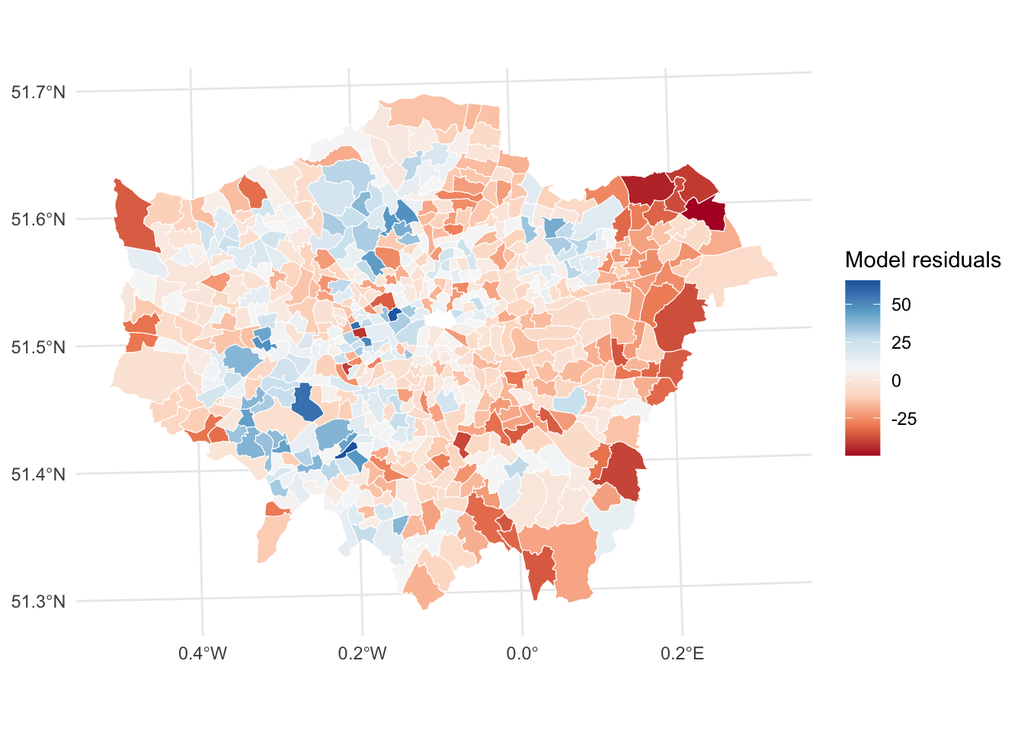

```r
ggplot(Regressiondata) +
  geom_sf(aes(fill = residuals), color = 'white', size = .2) +
  scale_fill_distiller(
  type = "div",
  palette = 5,
  direction = 1,
  aesthetics = "fill"
) +
  coord_sf() +
  theme_minimal() +
  labs(fill = 'Model residuals')
```

Another thing that we can explore is the spatial distribution of the model residuals. Ideally, the model residuals should not be spatially auto correlated. Here we can see that this is not the case, we can add a spatial term in the regression model to account for the spatial auto correlation.